# Logistics_Summary

Alison Bean de Hz

2024-09-14

# Understanding regressions

- Regression is modeling the expected (mean/average) response conditional on the predictors
- For a binary (0/1) response, the expected value is just the probability of the event
- Why can’t we do OLS:
  1. Probabilities are bounded between 0 and 1, and linear models are not bounded.
  2. Because there is a non-linear relationship between the target and the logged odds. OLS assumes that the relationship between the dependent and independent variables is linear, which is not the case. The S shape of the logistic regression curve. The rate of change of the probability varies as the X’s vary.
  3. OLS properities do not hold.
  - The errors are normally distributed witha mean of zero is not true with logistic regression
  - The errors have constant variance is also not true with logistic regression.
  - Logistic Regressions follow the binomial distribution

## Logit Link Transformation

- To create a linear model, a link function (logit) is applied to the probabilities.
- The relationship between the parameters and the logits are linear.
- Logits are unbounded.

## Odds ratios from the logits

- e^(coefficient) = Odds
- 100 * (Odds - 1) = %
- To double the odds = log(2) / coefficient

## Maximum Likelihood estimation & Likelihood Ratio Tests

- In logistic regression, estimates are obtained via maximum likelihood estimation (MLE)
- Likelihood estimation provides a basis for hypothesis testing.
- Likelihood Ratio Test (LRT) compares these FULL and REDUCED models.
  - FULL – Bigger of the two models you are comparing.
  - REDUCED – Smaller, nested model of the two.
  - Null: Adding a specific variable does not provide more information
  - Alt: Adding a specific variable provides more information.
- For continuous variables to be in the model, there needs to be linear relationship between X and Y. To test the assumption perform a general additive model (GAM). If the line is straight and the EDF is around 1, then it passes the linearity test. GAMs use splines
  - ID the assumptions for the GAMs fail,
    1. Use GAM logistic model instead with more limited interpretation on variables that break assumption
  2. Bin the continuous variables and no longer have that problem.

# Data Considerations

## Rare events

- Rare event modeling is dealing with having a target that is rare (5% of less of the data)
- Solutions to rare events include:
  1. Oversampling (creating more instances of the event)
  - Duplicate current event cases in training set to balance better with non-event cases.
  - Keep test set as original population proportion.
  2. Undersampling (taking less of the non-event)
  - Randomly sample current non-event cases to keep in the training set to balance with event cases.
  - Keep test set as original population proportion.
- By over or under sampling, you have introduced bias into the data. You need to correct for that.
  - Weighted Observations: Most common solution
    - Instead of adjusting the model after it is built, weighting observations adjusts while the model is being built.
    - Uses weighted MLE instead – each observation has potentially different weight to the MLE calculation.
  - Adjust the intercept: Only for small samples, and only when you know the model is correct (not really used in real-world)

## Missing Values

1. Delete: If a majority of your data is missing, then consider deleting the variable all together.
2. If categorical - make a “missing” category
3. If continuous - simple mean, or predictive modeling
- Be careful about multicollinearity.

## Convergence problems

- Complete linear separation occurs when some combination of the predictors perfectly predict every outcome
- Quasi-complete separation occurs when the outcome can be perfectly predicted for only a subset of the data
- Possible solultions to separation:
  - Collapse the categories of the predictor variable to eliminate the 0 cell count.
  - Penalized maximum likelihood.
  - Eliminate the category altogether – probably not reasonable since the category seems important!
  - Add a very small constant to the cell counts.

# Assessing Predictive Power

- There are two main ways to assess the predictive power
  1. Probability-based metrics
  2. Classification-based metrics: based on whether the predicted probability exceeds some threshold
- Probability measures include:
  - Coefficient of determination
  - Concordance, discordances, and ties
- Classification measures include:
  - Sensitivity vs. Specificity
    - Area under te ROC curve
    - KS Statistic
  - Precision vs. Recall
    - Lift Chart
    - Gain Chart
  - Accuracy vs. Error

## Classification: Sensitivity vs. Specificity

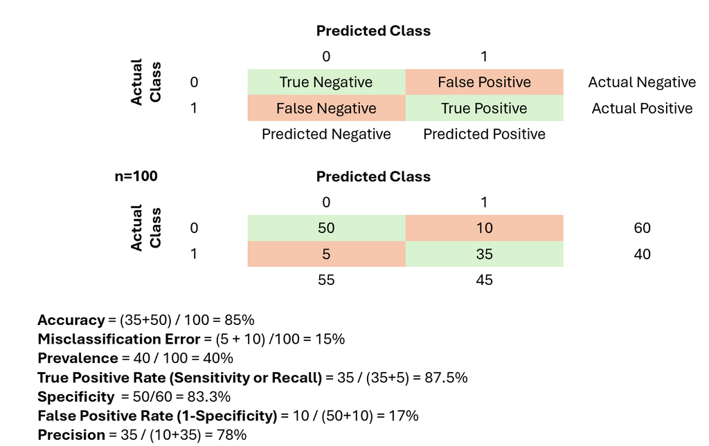

- Sensitivity: True Positive Rate - % of actual 1s are classified as 1s

$$TPR = TruePositive / (TruePositive +
FalseNegative)$$

- Specificity: True Negative Rate - % of actual 0s are classified as 0s

$$TNR = TrueNegative/ (TrueNegative +
FalsePositives)$$

- 1 - Specificity = False Positive Rate

$$FalsePositiveRate = (FalsePositives)
/(TrueNegatives + False Positives)$$

### Cut-offs

- Always consider the cost of false positives and false negatives when doing classification.
- When NOT considering costs, many different techniques to “optimal” cut-off.
  1. Youden’s index : J = (sensitivity + specificity) - 1
  2. K-S Statistic
- ROC Curve - plots the true positive rate (sensitivity) and the false positive rate (1-specificity)
  - You want high sensitivity and high specificity.
  - On the graph, high sensitivity vs. low false positive rate
  - Area under the ROC curve = % concordance + 1/2 (%Tied)
    - This is the c-statistic from the concordance section
  - Optimal point on the graph is Youden’s Index
- K-S Statistic (Kolmogorov-Smirnov)
  - Popular in banking and finance
  - K-S D-statistics = Youden’s Index
    - max(sensitivity + specificity - 1)
    - maximum difference between TPR and FPR
  - K-S Graph has two cumulative distribution functions
    - G(c) = cumulative proportion of true positives
    - F(c) = cumulative proportion of false positives
    - KS Statistic = maximum difference between the two CDFs
    - KS Cutoff = the cutoff (threshold) value of the classifier where the K-S statistic is maximized.
  - The K-S statistic measures how well the model differentiates between positive and negative instances. A higher K-S statistic indicates better separation, meaning the model does a good job of assigning higher probabilities to positive cases and lower probabilities to negative cases.

### Recall and Precision

- Recall = Sensitivity = True Positive Rate - % of actual 1s are classified as 1s
- Precision = Out of the 1s predicted, how many were actually 1s.
- Optimal cutoff when looking at precision:
  - “Optimal” – precision and recall are weighed equally, so select cut-off that produces highest $F_1$ score.
  - $F_1$ DOES **NOT** TYPICALLY MATCH YOUDEN CUT-OFF

  $$F_1 = 2(Precision*Recall / Precision +
  Recall)$$

### Precision & Lift

$$Lift = Positive Predicted Values /
\pi_1$$

- PPV (Positive Predictive Value or Precision) represents the proportion of true positive predictions in the top ranked group (such as the top X% of customers ranked by predicted probability).
- π₁ represents the overall proportion of positives (e.g., the percentage of customers who respond in the entire population).
- In practical terms, if your model has a lift of 2 for the top 10% of customers, it means that you’re twice as likely to find responders in that top 10% compared to randomly selecting 10% of your customers.
- The top depth% of your customers, based on predicted probability, you get lift times as many responses compared to targeting a random sample of depth% of your customers.
  - Trying to not just randomly select customers. Instead, it is breaking the data into depths. Example was groups of 10% intervals (buckets).
- Example interpretation:
  - Lift = (precision / drawing at random)
  - In the top 10%, if you assumed all were 1s, then the model would be right 97.6% of the time.
  - However, if you randomly select homes, you’ll probably only be right 41% of the time.
  - Lift = my model is 2.4 times more likely to identify bonus eligible homes when you look at the top 10% of our data.
  - You get 2.4 times more bonus eligible homes than if you randomly selected the data.
  - Our lift declines as we go down the buckets. The more observations you add in, the more likely your model is to be wrong.
- Lift Curve / Response Rate Chart
  - Real lift will bottom out at zero (real lift is bucket by bucket)
  - Cumulative lift will bottom out at 1 (includes all the previous buckets)
  - There is an upper bound on lift because the max response rate is 1.
  - You can compare lift in the same dataset, but be careful comparing across datasets.
- Capture rate = gains rate = Of all of the 1s in the dataset, what proportion of them exist in that bucket.

### Classification Closing

- Classification is a decision that is extraneous to statistical modeling.
- Although logistic regression tends to work well in classification, it is a probability model and does not output 1’s and 0’s.
- Classification assumes cost for each individual is the same.
  - Useful for groups.
  - Careful about single observation decisions.

# ORDINAL LOGISTIC REGRESSION

- When the outcomes are ordered we can generalize the binary logistic regression model.
  - Ex: Disagree, Neutral, Agree
  - EX: Tropical Depression, Tropical Storm, Category 1, 2, 3, 4, 5 Hurricanes
- Tree methods for modeling ordinal logistic regression models:
  1. **Cumulative Logit Model**: Easy to implement and interpret!
  2. Adjacent Categories Model
  3. Continuation Ratio Model

## Cumulative Logit Model

- Instead of modeling the typical logit, we will model the cumulative logits.
  - If an ordinal variable has m levels with probabilities, then the cumulative logits are: p1, p2, … pm-1. (you’ll have one less model than there are categories – kind of like a dummy having one less category)
  - m-1 Binary Logistic Regressions!
- Output will have the same coefficients and different intercepts
  - Assumption is that they are parallel lines, but we must test is the slopes are actually parallel.
- We will use the Brant or score test to check and see if the slopes are the same.
  - Null: Slopes are equal (We want high p-values – do not want to reject)
  - Alternative: Slopes are not equal (we don’t know which slopes, but that at least one pair of slopes will fail)
  - Omnibus test is a global test to see if any pair does not pass. Then it has each pair to show which pair failed the test.
- If the brant test fails:
  1. Partial Proportional Odds Model - Some of the variables fail assumptions
  2. Multinomial Logistic Regression - All variables fail assumptions

### Interpretation example:

- The interpretations can only show general direction.
  - You predict the direction of the outcome, not the specific outcome like we did for just binary targets.
- Males have 65.35% lower expected odds of being in a higher ethical category as compared to non-males.
- Business school students have 52.24% lower expected odds of being in a higher ethical category as compared to students not in the business school.